# Introdução à Ciência de Dados

Mestrado em Administração  
Aula 10

Prof. Washington Santos da Silva

IFMG - Campus Formiga

14 de maio de 2026

## Nesta Aula

**Módulo de Probabilidade e Simulação**

Esta é a terceira aula do módulo:

1. Fundamentos de probabilidade
2. Variáveis aleatórias e distribuições de probabilidade
3. **Distribuições essenciais, simulação e ponte para inferência**
4. Simulação de Monte Carlo em Finanças: VPL, VaR e Expected Shortfall

## Contexto

**Onde estamos no CRISP-DM?**

Probabilidade entra quando precisamos transformar incerteza em uma linguagem operacional para pesquisa empírica.

Nesta aula, o objetivo não é esgotar distribuições, simulação ou inferência. O objetivo é consolidar fundamentos para:

- reconhecer distribuições como modelos para processos incertos;
- entender como números pseudoaleatórios sustentam simulações;
- interpretar médias amostrais, aproximação e erro;
- praticar essas ideias em exercícios.

# Distribuições de Probabilidade como Modelos Teóricos

> “Essentially, all models are wrong, but some are useful.”

— George E. P. Box e Norman R. Draper, *Empirical Model-Building and Response Surfaces* (1987)

## Modelos teóricos

**Modelos como aproximações úteis**

Na ciência, modelos teóricos não reproduzem perfeitamente a realidade.

Eles simplificam o fenômeno para tornar possível:

- interpretar padrões observáveis;
- formular hipóteses;
- fazer previsões;
- comparar teoria e evidência empírica.

Distribuições de probabilidade cumprem esse papel quando modelamos incerteza.

## Distribuições como modelos teóricos

**Modelos para padrões de incerteza**

De forma semelhante, em Probabilidade e Estatística, distribuições de probabilidade descrevem padrões esperados de variabilidade.

Elas indicam:

- quais valores podem ocorrer;
- quais valores são mais prováveis;
- como a incerteza se distribui;
- quais parâmetros controlam posição, dispersão ou forma.

i.e, uma distribuição de probabilidade não é apenas uma fórmula: é uma representação idealizada do **processo real que produziu os dados**.

## Distribuição como hipótese

**Uma distribuição é um modelo para a incerteza**

Quando escolhemos uma distribuição, fazemos uma hipótese sobre o **processo gerador de dados**: o processo que produziu as observações.

A distribuição não é o PGD real; ela é um modelo probabilístico simplificado desse processo.

Essa hipótese envolve perguntas como:

- quais valores são possíveis?
- quais valores são mais prováveis?
- como a variabilidade se comporta?
- quais parâmetros controlam posição, dispersão ou forma?

A distribuição pode ser útil, mas deve ser interpretada como aproximação — não como cópia perfeita da realidade.

## Distribuições de Probabilidade

**Roteiro para usar uma distribuição**

Portanto, não queremos decorar distribuições. Queremos usá-las como modelos probabilísticos para representar características essenciais do **processo gerador de dados**.

Para cada distribuição, devemos perguntar:

1. **Qual fenômeno aleatório** estamos tentando representar?
2. **Qual distribuição** é plausível para esse fenômeno?
3. **Quais parâmetros** controlam seu comportamento?
4. **Como calcular probabilidades e quantis**?
5. **Como simular valores** a partir desse modelo?

## Como escolher uma Distribuição?

**Do fenômeno à distribuição**

A escolha de uma distribuição deve começar pela pergunta:

> que características essenciais do processo gerador de dados queremos representar por meio de um modelo probabilístico?

## Como escolher uma distribuição?

**Do fenômeno à distribuição**

| Situação empírica | Característica modelada | Distribuição típica |
| --- | --- | --- |
| Ocorreu ou não ocorreu? | resultado binário | Bernoulli |
| Quantos sucessos em $n$ tentativas? | número de sucessos | Binomial |
| Quantos eventos ocorrem em um intervalo? | contagem com taxa média | Poisson |
| Valor contínuo em um intervalo | valores igualmente plausíveis | Uniforme |
| Valor contínuo aproximadamente simétrico | variação agregada | Normal |
| Valor positivo e assimétrico | efeitos multiplicativos | Log-normal |

## Do modelo aos dados Observados

**A ponte entre Probabilidade e Estatística**

Em **Probabilidade**, assumimos um modelo probabilístico para representar o PGD e estudamos os dados que esse modelo poderia produzir:

$$\text{modelo para o PGD} \longrightarrow \text{dados possíveis}$$

Em **Inferência Estatística**, observamos dados e buscamos aprender sobre o PGD por meio de modelos probabilísticos plausíveis:

$$\text{dados observados} \longrightarrow \text{modelos plausíveis para o PGD}$$

Assim:

- Probabilidade: **assume um modelo para o Processo Gerador dos Dados**.
- Inferência Estatística: **aprende sobre o Processo Gerador dos Dados por meio dos dados**.

# Distribuições de Probabilidade Discretas

## Distribuição de Bernoulli

**Princípios Fundamentais**

- Considere um fenômeno aleatório que pode produzir somente dois resultados possíveis denominados “sucesso” (1) e “falha” (0).
- Considere ainda que os dois resultados possíveis são **mutuamente exclusivos** e **exaustivos**
- Considere ainda que a probabilidade de “sucesso” seja $p$ e de “falha” seja $(1 - p)$.
- O fenômeno aleatório com essas características é denominado um **ensaio de Bernoulli**.

## Distribuição de Bernoulli

**Função de Probabilidade**

Se $X$ é uma variável aleatória que representa este fenômeno:

$$X =
\begin{cases}
1, & \text{se o evento ocorre},\\
0, & \text{se o evento não ocorre}.
\end{cases}$$

Se $P(X=1)=p$, então a função de probabilidade de $X$ é:

$$P(X = x|p) =
\begin{cases}
p & \text{se } x = 1 \\
1 - p & \text{se } x = 0
\end{cases}$$

Ou de forma mais compacta:
$$P(X = x|p) = p^x(1 - p)^{1 - x} \,\,\, \text{para}\,\, x = \{0,1\}$$

Nesse caso, escrevemos $X \sim \text{Bernoulli}(p)$, que significa: $X$ tem distribuição de Bernoulli com parâmetro $p$.

## Distribuição de Bernoulli

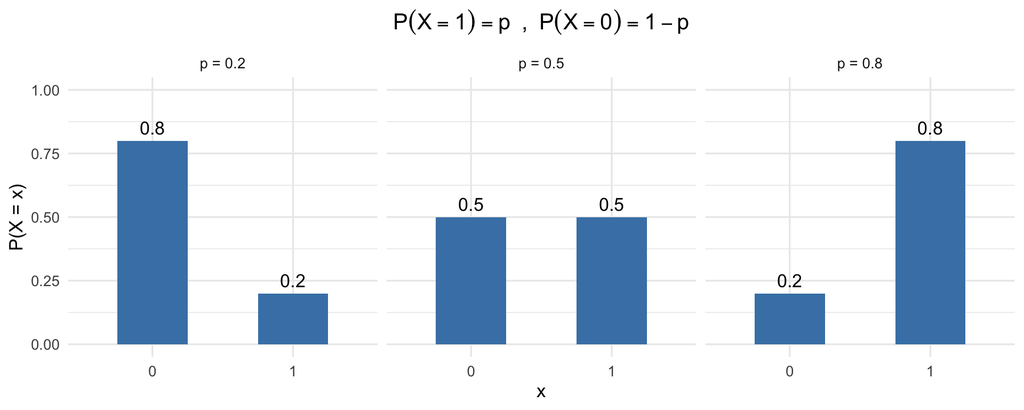

Função de probabilidade de uma variável aleatória com distribuição de Bernoulli para diferentes valores de $p$.

## Distribuição de Bernoulli

**Aplicações em Finanças**

- **Risco de crédito corporativo**: $X = 1$ se a empresa devedora entra em default em um horizonte fixo, por exemplo, 12 meses; $X = 0$ caso contrário.
- **Risco de crédito ao consumidor**: $X = 1$ se o contrato fica inadimplente até determinada data, segundo um critério definido; $X = 0$ se permanece adimplente.
- **Decisão de concessão de crédito**: $X = 1$ se a proposta de crédito é aprovada pela instituição; $X = 0$ se é rejeitada.
- **Classificação binária de risco de crédito**: $X = 1$ se o cliente é classificado como “mau” pagador; $X = 0$ se é classificado como “bom” pagador.
- **Detecção de fraude**: $X = 1$ se a transação é fraudulenta; $X = 0$ se é legítima.

## Momentos da Distribuição de Bernoulli

**Momentos**

- **Valor Esperado (Média)**

$$\begin{align}
E(X) &= \sum_{i=1}^{n} x_i P(X = x_i) \\
&= 0 \times P(X = 0) + 1 \times P(X = 1) \\
&= 0 \times (1 - p) + 1 \times p \\
&= p
\end{align}$$

- **Variância**

$$\begin{align}
V(X) &= E[(X - E(X))^2] \,\,\, \text{definição}\\
&= E(X^2) - E(X)^2\\
&= E(X^2) - p^2
\end{align}$$

Como podemos calcular $E(X^2)$?

## Momentos da Distribuição de Bernoulli

**Valor Esperado de Funções de Variáveis Aleatórias**

$$\begin{align}
E(g(X)) &= \sum_{\text{todo x}} g(x)P(X = x) \,\,\, \text{(VA discreta)}\\
E(g(X)) &= \int_{-\infty}^{\infty}g(x)f(x)dx \,\,\, \text{(VA contínua)}
\end{align}$$

Em nosso caso:

$$\begin{align}
E(X^2) &= \sum_{\text{todo x}} g(x)P(X = x) \\
&= \sum_{\text{todo x}} x^2 P(X = x) \\
&= 0^2 \times P(X = 0) + 1^2 \times P(X = 1) \\
&= 0^2 \times (1 - p) + 1^2 \times p \\
&= p
\end{align}$$

## Momentos da Distribuição de Bernoulli

**Derivação da Variância**

Usando o resultado anterior:

$$\begin{align}
V(X) &= E[(X - E(X))^2] \,\,\, \text{definição}\\
&= E(X^2) - E(X)^2\\
&= E(X^2) - p^2 \\
&= p - p^2 \\
&= p(1-p)
\end{align}$$

## Distribuição de Bernoulli em R

**Funções**

A distribuição de Bernoulli é um caso especial da distribuição binomial.

Em R, usamos as funções da binomial com `size = 1`.

| Função | O que retorna | Uso na Bernoulli |
| --- | --- | --- |
| `dbinom(x, 1, p)` | $P(X = x)$ | Probabilidade de obter `0` ou `1` |
| `pbinom(q, 1, p)` | $P(X \leq q)$ | Probabilidade acumulada até `q` |
| `qbinom(a, 1, p)` | Menor valor de `x` com $P(X \leq x) \geq a$ | Quantil associado a uma probabilidade acumulada `a` |
| `rbinom(n, 1, p)` | `n` sorteios de uma Bernoulli | Gera uma amostra de zeros e uns |

## Simulando uma Bernoulli em R

**Bernoulli como caso especial da Binomial**

Com R, simulamos um valor de uma variável aleatória com distribuição de Bernoulli usando `rbinom()` com `size = 1`:

```r
rbinom(n = 1, size = 1, prob = 0.30)
```

- `prob = 0.30`: probabilidade de obter $X = 1$.
- `size = 1`: cada observação é um único ensaio de Bernoulli.
- `n = 1`: gera uma observação.

O resultado será `0` ou `1`.

## Gerando várias Bernoullis

**O papel de `n`**

Para gerar várias observações Bernoulli, mantemos `size = 1` e aumentamos `n`:

```r
rbinom(n = 10, size = 1, prob = 0.30)
```

Esse comando gera 10 valores independentes:

```
0 1 0 0 1 0 0 0 1 0
```

Cada valor é uma realização de uma variável Bernoulli com parâmetro $p = 0.30$.

## Cuidado com `n` e `size`

**Eles não significam a mesma coisa**

```r
rbinom(n = 10, size = 1, prob = 0.30)
```

gera **10 observações Bernoulli**.

```r
rbinom(n = 1, size = 10, prob = 0.30)
```

gera **1 observação Binomial**, isto é, o número de sucessos em 10 ensaios.

Portanto:

- `n`: quantos valores o R gera;
- `size`: quantos ensaios de Bernoulli entram em cada valor gerado.

## Distribuição Binomial

**Princípios fundamentais do processo gerador**

- Considere $n$ ensaios de Bernoulli, representados pelas variáveis aleatórias $X_1,\ldots,X_n$.
- Cada ensaio possui a mesma probabilidade de sucesso: $P(X_i = 1) = p$ e $P(X_i = 0) = 1-p$, para todo $i = 1,\ldots,n$.
- Os ensaios são **independentes** entre si.
- Se $Y$ representa o número **total** de sucessos nos $n$ ensaios:

$$Y = X_1 + X_2 + \cdots + X_n = \sum_{i=1}^{n} X_i,$$

então escrevemos: $Y \sim \text{Binomial}(n,p)$.

## Distribuição Binomial

**Função (Massa) de Probabilidade**

Se $Y \sim \text{Binomial}(n,p)$, então $Y$ representa o número de sucessos em $n$ ensaios de Bernoulli independentes, todos com a mesma probabilidade de sucesso $p$.

$$P(Y = y \mid n,p) =
\binom{n}{y} p^y(1-p)^{n-y},
\quad y \in \{0,1,\ldots,n\}.$$

Explicação:

- $p^y(1-p)^{n-y}$ é a probabilidade de uma sequência específica com $y$ sucessos e $n-y$ fracassos.
- $\binom{n}{y}$ é o número de sequências distintas que produzem o mesmo total $Y = y$.

Por exemplo, se $n = 3$ e $y = 2$, as sequências $(1,1,0)$, $(1,0,1)$ e $(0,1,1)$ resultam em $Y = 2$.

## Momentos da Distribuição Binomial

**Média e Variância**

Se $Y \sim \text{Binomial}(n,p)$, então:

- $E(Y) = np$
- $V(Y) = np(1 - p)$

## Distribuição Binomial

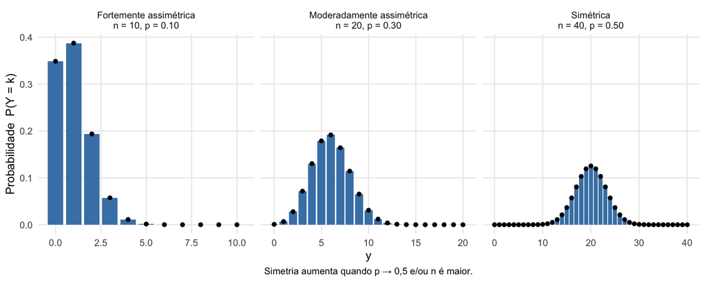

Função de probabilidade de uma variável aleatória com distribuição binomial para diferentes valores de $n$ e $p$.

## Distribuição Binomial

**Aplicações em Finanças**

- **Número de defaults em uma carteira de crédito homogênea**: $X$ representa o número de empresas devedoras que entram em default, entre $n$ empresas com mesma probabilidade de default, acompanhadas em um horizonte fixo, por exemplo, 12 meses.
- **Número de contratos inadimplentes em crédito ao consumidor**: $X$ representa o número de contratos que ficam inadimplentes, entre $n$ contratos semelhantes observados até determinada data, segundo um critério definido.
- **Número de propostas de crédito aprovadas sob uma mesma política**: $X$ representa o número de propostas aprovadas, entre $n$ propostas semelhantes avaliadas pela instituição em determinado período.
- **Número de transações fraudulentas**: $X$ representa o número de transações fraudulentas, entre $n$ transações comparáveis observadas em determinado período.

## Distribuição de Poisson

**Princípios fundamentais do processo gerador**

A distribuição de Poisson é usada para modelar o **número de ocorrências** de um evento em um intervalo fixo de tempo, espaço ou exposição.

Ela é especialmente adequada quando:

- a variável de interesse é uma **contagem**: $0, 1, 2, \ldots$;
- as ocorrências podem ser tratadas como eventos **pontuais** ao longo de um intervalo contínuo;
- ocorrências em intervalos disjuntos podem ser tratadas como **independentes**;
- a taxa média de ocorrência é aproximadamente **constante** no intervalo analisado;
- em intervalos muito pequenos, a chance de mais de uma ocorrência é desprezível.

Se $Y$ representa o número de ocorrências no intervalo analisado, escrevemos: $Y \sim \text{Poisson}(\lambda)$ em que $\lambda > 0$ representa o número esperado de ocorrências nesse intervalo.

## Distribuição de Poisson

**Função de Probabilidade**

Se $Y \sim \text{Poisson}(\lambda)$, então $Y$ representa o número de ocorrências de um evento em um intervalo fixo.

A função de probabilidade de $Y$ é:

$$P(Y = y \mid \lambda) =
\frac{\lambda^y e^{-\lambda}}{y!},
\quad y \in \{0,1,2,\ldots\}.$$

Para valores fora desse conjunto, $P(Y = y \mid \lambda) = 0$.

Interpretação:

- $y$ é o número de ocorrências cuja probabilidade queremos calcular.
- $\lambda$ é o número esperado de ocorrências no intervalo analisado.
- Como $Y$ é uma contagem, seus valores possíveis são inteiros não negativos.

## Momentos da Distribuição de Poisson

**Média e Variância**

Se $Y \sim \text{Poisson}(\lambda)$, então:

- $E(Y) = \lambda$
- $V(Y) = \lambda$

Uma característica importante da distribuição de Poisson é que a média e a variância são iguais.

## Distribuição de Poisson

**Aplicações em Finanças**

- **Número de sinistros em seguros**: $X$ representa o número de sinistros registrados em uma carteira de seguros durante um período fixo, por exemplo, um mês ou um ano.
- **Número de negociações em mercado financeiro**: $X$ representa o número de negociações de um ativo em uma janela fixa de tempo, por exemplo, 1 minuto ou 5 minutos.
- **Número de transações financeiras**: $X$ representa o número de transações realizadas em uma conta, cartão ou sistema de pagamentos em uma janela de tempo bem definida.
- **Número de reclamações de clientes**: $X$ representa o número de reclamações recebidas por uma instituição financeira em um intervalo fixo, por exemplo, uma semana ou um mês.

## Distribuição de Poisson em R

**Funções**

Em R, usamos a família de funções da Poisson com parâmetro `lambda`.

| Função | O que retorna | Uso na Poisson |
| --- | --- | --- |
| `dpois(x, lambda)` | $P(X = x)$ | Probabilidade de observar exatamente `x` ocorrências |
| `ppois(q, lambda)` | $P(X \leq q)$ | Probabilidade acumulada até `q` ocorrências |
| `qpois(a, lambda)` | Menor valor de `x` com $P(X \leq x) \geq a$ | Quantil associado a uma probabilidade acumulada `a` |
| `rpois(n, lambda)` | `n` sorteios de uma Poisson | Gera uma amostra de contagens com média `lambda` |

## Processo gerador e escolha da distribuição

**O que está sendo contado?**

- A distribuição de Poisson é mais apropriada quando contamos ocorrências em um intervalo fixo de tempo, espaço ou exposição, sem definir previamente um número máximo de tentativas.
- Na distribuição binomial, por outro lado, contamos sucessos em um número fixo de ensaios previamente definidos, como $n$ contratos, $n$ clientes ou $n$ propostas de crédito.

# Distribuições de Probabilidade Contínuas e Simulação

## Distribuição Uniforme Contínua

**Princípios fundamentais do processo gerador**

Para distribuições uniformes contínuas, a probabilidade de $Y$ estar em um certo sub-intervalo $[a,b]$ depende somente do comprimento do intervalo.

## Distribuição Uniforme Contínua

**Função densidade de Probabilidade**

Se $Y$ é uma VA que satisfaz à condição anterior, então, a função densidade probabilidade de $Y$ é dada por:

$$f_Y(y)=
\begin{cases}
\frac{1}{b - a} & \text{se } a \leq y \leq b \\
0 & \text{caso contrário}
\end{cases}$$

#### Momentos

$E(Y) = \frac{a + b}{2}$

$V(Y) = \frac{(b - a)^2}{12}$

## Distribuição Uniforme Contínua

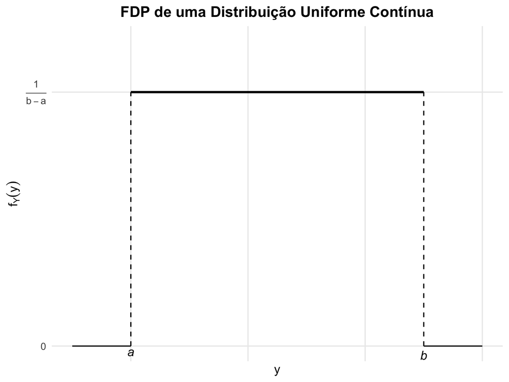

## Distribuição Uniforme Contínua

**Aplicações**

- **Métodos de Simulação de Monte Carlo:** a distribuição uniforme contínua é a base de todos os métodos de simulação.
- **Preços em leilões simulados:** Em experimentos de leilões, é comum assumir que os lances iniciais dos participantes são extraídos de uma uniforme.
- **Pesquisas de Marketing:** ao simular escolhas quando não há informação prévia, pode-se assumir que a propensão inicial dos consumidores a escolher entre duas marcas segue uma distribuição uniforme.
- **Inferência Bayesiana**: Distribuição a priori não informativa. Métodos de Simulação de Monte Carlo via Cadeias de Markov

## Distribuição Uniforme em R

**Funções**

Em R, usamos a família de funções da uniforme contínua com limites `min` e `max`.

| Função | O que retorna | Uso na uniforme contínua |
| --- | --- | --- |
| `dunif(x, min, max)` | $f(x)$ | Valor da densidade no ponto `x` |
| `punif(q, min, max)` | $P(X \leq q)$ | Probabilidade acumulada até `q` |
| `qunif(a, min, max)` | Valor de `x` com $P(X \leq x) = a$ | Quantil associado a uma probabilidade acumulada `a` |
| `runif(n, min, max)` | `n` sorteios de uma uniforme contínua | Gera uma amostra de valores entre `min` e `max` |

## Distribuição Normal (Gaussiana)

**Importância**

- A distribuição normal é a distribuição de probabilidade mais importante em estatística e econometria, teóricas e aplicadas.
- Muitos estimadores e estatísticas de testes possuem a distribuição normal como distribuição assintótica.
- Consequentemente, é importante entender as propriedades da distribuição normal e aquelas que dela derivam.

## Distribuição Normal (Gaussiana)

**Descrição**

Uma variável aleatória $Y$ com distribuição normal, representada por $Y \sim N(\mu, \sigma^2)$, possui função densidade de probabilidade dada por:

$$f(y) = \frac{1}{\sigma \sqrt{2\pi}} e^{-\frac{(y-\mu)^2}{2\sigma^2}}$$

Com $y \in \mathbb{R}$, $\mu \in \mathbb{R}$ e $\sigma > 0$.

#### Distribuição Normal Padrão

Quando padronizamos $Y$ com $Z = \frac{Y - \mu}{\sigma}$, temos $\mu = 0$ e $\sigma = 1$, o que origina a distribuição normal padronizada e sua fdp é usualmente representada por $\phi(y)$ e sua função de distribuição por $\Phi(y)$.

#### Função de Distribuição Acumulada

A função de distribuição acumulada padronizada não está disponível em forma fechada, mas é escrita como:

$$\Phi(y) = \int_{-\infty}^y \phi(u) du$$

#### Momentos

- $E[X] = \mu$ (parâmetro de locação)
- $V[X] = \sigma^2$ $\rightarrow$ $\sigma = \sqrt{\sigma^2}$ (parâmetro de escala)

## Distribuição Normal Padronizada

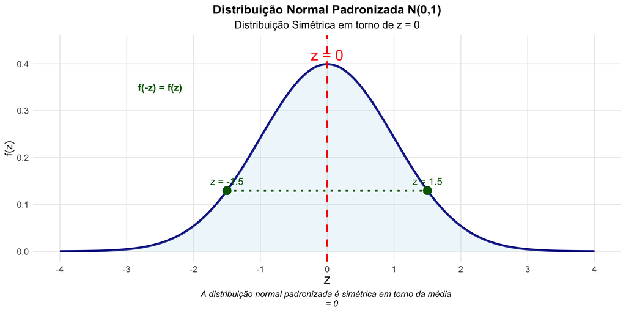

## Distribuição Normal (Gaussiana)

**Distribuicão da Soma de Variáveis Aleatórias**

Há muitas coisas espsecias sobre a distribuição normal, e uma das propriedades mais úteis é a seguinte:

#### Teorema

Se $X_1, X_2,\ldots, X_n$ são variáveis aleatórias independentes, com $X_i \sim N(\mu_i, \sigma_i^2)$, então a soma destas variáveis aleatórias também possui distribuição normal:

$$Y = \sum_{i = 1}^n X_i \sim N(\sum_{i = 1}^n \mu_i, \sum_{i = 1}^n \sigma_i^2)$$

## Distribuição Normal

**Importância e Aplicações**

- **Importância Teórica:** é a base dos métodos de inferência estatística. É a base dos modelos de regressão linear e de vários outros métodos estatísticos e econométricos.
- **Finanças:** Valor-em-Risco (VaR) sob hipótese paramétrica de normalidade dos retornos; essa hipótese funciona como benchmark, não como descrição universal dos retornos financeiros.
- **Auditoria:** Modelagem de erros contábeis e fraudes. A distribuiçõa normal é usada como benchmark em auditorias. Desvios sistemáticos da normal sugerem manipulações ou fraudes.
- **Simulação de Monte Carlo:** Muito usada para simular diversas variáveis aleatórias.

## Distribuição Normal em R

**Funções**

Em R, usamos a família de funções da normal com média `mean` e desvio-padrão `sd`.

| Função | O que retorna | Uso na normal |
| --- | --- | --- |
| `dnorm(x, mean, sd)` | $f(x)$ | Valor da densidade no ponto `x` |
| `pnorm(q, mean, sd)` | $P(X \leq q)$ | Probabilidade acumulada até `q` |
| `qnorm(a, mean, sd)` | Valor de `x` com $P(X \leq x) = a$ | Quantil associado a uma probabilidade acumulada `a` |
| `rnorm(n, mean, sd)` | `n` sorteios de uma normal | Gera uma amostra com média `mean` e desvio-padrão `sd` |

## Distribuição Log-normal

**Valores positivos e assimétricos**

Se $\log(Y)$ tem distribuição Normal, então $Y$ tem distribuição Log-normal.

Essa distribuição é útil quando a variável:

- só pode ser positiva;
- apresenta assimetria à direita;
- pode ser interpretada como resultado de crescimento multiplicativo.

Exemplos: preços, renda, riqueza, custos e fluxos positivos.

## Distribuição Log-normal em R

**Funções**

Em R, usamos a família de funções da log-normal com parâmetros `meanlog` e `sdlog`.

| Função | O que retorna | Uso na log-normal |
| --- | --- | --- |
| `dlnorm(x, meanlog, sdlog)` | $f(x)$ | Valor da densidade no ponto `x` |
| `plnorm(q, meanlog, sdlog)` | $P(X \leq q)$ | Probabilidade acumulada até `q` |
| `qlnorm(a, meanlog, sdlog)` | Valor de `x` com $P(X \leq x) = a$ | Quantil associado a uma probabilidade acumulada `a` |
| `rlnorm(n, meanlog, sdlog)` | `n` sorteios de uma log-normal | Gera uma amostra de valores positivos com assimetria à direita |

## Distribuições Paramétricas

**Descrição**

Acredito que a partir dos slides anteriores, vocês compreendam melhor os seguintes conceitos.

#### Conceitos

- Uma **distribuição paramétrica** $f(x|\theta)$ é uma distribuição indexada por um parâmetro $\theta \in \Theta$.
- Para cada $\theta$, a função $f(x|\theta)$ é uma função de probabilidade válida. À medida que $\theta$ varia, a função de probabilidade muda.
- Portanto, é desejável entender como a variação nos parâmetros leva à variação na forma da distribuição.
- O conjunto $\Theta$ é chamado de *espaço de parâmetros*. Assim, muitas vezes, chamamos $f(x|\theta)$ de uma **família de distribuições**.
- Os parâmetros da distribuição devem ser **estimados** para verificar se uma distribuição é consistente com os dados observados (A inferência estatística “aprende sobre o Processo Gerador dos Dados por meio dos dados”).

# A Ponte entre a Probabilidade e a Inferência Estatística

> “Although this may seem a paradox, all exact science is dominated by the idea of approximation.”

— Bertrand Russell, *The Scientific Outlook* (1931)

## A Média Amostral

**Descrição**

- A **média amostral** é a média aritmética de $n$ variáveis aleatórias (ou realizações) de uma amostra aleatória de tamanho $n$, denotada por:

$$\begin{align*}
\overline{X}_n &= \frac{X_1 + X_2 + \ldots + X_n}{n}, \\
\overline{X}_n &= \frac{\sum_{i=1}^n X_i}{n}
\end{align*}$$

- Também chamamos a média aritmética das realizações dessas $n$ variáveis aleatórias de média amostral.
- Por enquanto, vamos nos concentrar no que é esse objeto e como ele se comporta.

## A Média Amostral

**É uma Função de Variáveis Aleatórias**

$$\overline{X}_n = \frac{\sum_{i=1}^n X_i}{n}$$

- Os $X_i$ são variáveis aleatórias, então $\overline{X}_n$ é também uma variável aleatória, pois ela é uma **função de variáveis aleatórias**.
- Então, precisamos descobrir qual a sua **distribuição de probabilidade**.
- Vamos usar apenas as propriedades dos momentos para descobrir os momentos de $\overline{X}_n$ como funções dos momentos dos $X$s.

## A Média Amostral

**Valor Esperado da Média Amostral**

$$\begin{align*}
E[\overline{X}_n] &= E\left[\frac{\sum_{i=1}^n X_i}{n}\right] \, \text{(por definição)}\\
&= \frac{1}{n} \sum_{i=1}^n E[X_i] \, \text{(pelas propriedades do valor esperado)}\\
&= \frac{1}{n} \sum_{i=1}^n \mu \, \text{(apenas mudando a notação)}\\
&= \frac{1}{n} \cdot n\mu \\
E[\overline{X}_n] &= \mu
\end{align*}$$

A **distribuição** da média amostral é centrada em torno da média $\mu$ da população original.

## A Média Amostral

**Variância da Média Amostral**

$$\begin{align*}
V[\overline{X}_n] &= V\left[\frac{\sum_{i=1}^n X_i}{n}\right] \, \text{(por definição)} \\
&= \frac{1}{n^2} \sum_{i=1}^n V[X_i] \, \text{(as variáveis aleatórias Xs são independentes)}\\
&= \frac{1}{n^2} \sum_{i=1}^n \sigma^2 \, \text{(apenas mudando a notação)}\\
&= \frac{\sigma^2}{n} \\
V[\overline{X}_n] &= \frac{\sigma^2}{n}
\end{align*}$$

A **distribuição** da média amostral tem variabilidade menor que a distribuição original, tornando-se ainda menor à medida que $n$ aumenta.

## A Média Amostral

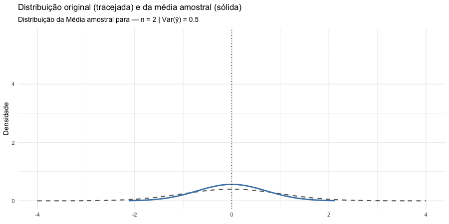

**Distribuição da Média Amostral**

- Temos uma função de um conjunto de variáveis aleatórias que compartilham uma média comum, e ela se torna mais concentrada em torno dessa média à medida que o tamanho do conjunto aumenta.

## Distribuição da Média Amostral

**Resultados Assintóticos**

- À medida que aumentamos o tamanho da amostra, a distribuição da média amostral revela comportamentos assintóticos fundamentais que são a base da estatística e da econometria.

#### Lei dos Grandes Números (LGN)

- Quando temos variáveis aleatórias i.i.d. com valor esperado finito, a média amostral converge para o valor esperado da população.
- Esse teorema fundamenta muitos métodos de simulação estatística, como os métodos de simulação de **Monte Carlo**, onde estimamos parâmetros populacionais por meio de médias amostrais.

#### Teorema Central do Limite (TCL)

- Mostra que, sob condições gerais, a distribuição da média amostral de VAs i.i.d. com variância finita se aproxima de uma distribuição normal à medida que o tamanho da amostra aumenta.
- O TCL é um dos resultados mais importantes e úteis de toda a teoria da probabilidade, que realmente serve como fundamento para a ciência estatística.

## Lei dos Grandes Números

**Teorema (versão fraca)**

Se $X_1, X_2, \dots, X_n$ são variáveis aleatórias independentes e identicamente distribuídas (i.i.d.), com $E[X_i] = \mu$ e $V(X_i) = \sigma^2 < \infty$, então:

$$\bar{X}_n = \frac{1}{n}\sum_{i=1}^{n} X_i
\;\xrightarrow[\;n\to\infty\;]{\;p\;}\;
\mu$$

Isso significa: **a média amostral converge em probabilidade para a média populacional**.

#### Tentativa de Tradução

- Quando repetimos um fenômeno aleatório muitas vezes de forma independente, a **média dos resultados observados** se aproxima da **média teórica ($E(X)$)** da variável aleatória de interesse à medida que aumentamos as repetições.

## Lei dos Grandes Números

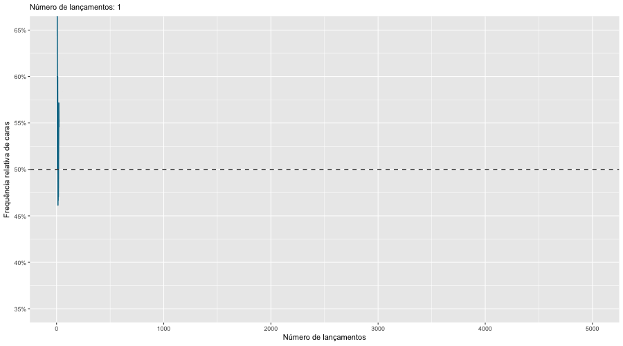

A proporção de “caras” pode oscilar no começo, mas com o tempo ela estabiliza perto de 0.5. A LGN garante esse comportamento para qualquer experimento aleatório com média finita

## Lei dos Grandes Números

**Por que isso importa?**

**Fundamenta os métodos de Simulação de Monte Carlo**: estimativas pela média amostral:

$$\hat\mu_n=\frac{1}{n}\sum_{i=1}^n g(X_i)
\;\xrightarrow[\;n\to\infty\;]{\;p\;}\;
\mathbb E[g(X)],$$

#### **O que diz a fórmula?**

Se você **repete um experimento aleatório muitas vezes**, calcula um número em cada repetição (o $g(X_i)$) e **faz a média** desses números, **essa média vai ficando cada vez mais próxima do valor verdadeiro** que queremos ($\mathbb E[g(X)]$).

#### **Tradução para Monte Carlo:**

Para estimar algo difícil de calcular diretamente, **simulamos muitos cenários**, computamos $g$ em cada um e **calculamos a média** — essa média é um **bom palpite** e **melhora quanto mais repetições** usamos.

## Teorema Central do Limite

**Versão de Lindeberg-Lévy**

Se $X_1,\ldots,X_n$ são variáveis aleatórias independentes e identicamente distribuídas (i.i.d.), com $E(X_i) = \mu$ e $V(X_i) = \sigma^2 < \infty$, então:

$$\frac{\bar X_n - \mu}{\sigma/\sqrt n}
= \frac{\sqrt n\,(\bar X_n - \mu)}{\sigma}
\xrightarrow{d} N(0,1) \quad (n \to \infty)$$

- A distribuição da média amostral padronizada **converge em distribuição** para uma distribuição normal padrão à medida que $n$ cresce.
- O TCL é um dos resultados mais poderosos e misteriosos da teoria da probabilidade e da estatística.
- **Ele mostra que o simples processo de tomar médias induz a normalidade**.
- A distribuição original não precisa ser normal; sob as condições do teorema, a média amostral padronizada terá distribuição aproximadamente normal em amostras grandes.
- Ou seja, não precisamos conhecer a distribuição que estamos amostrando para saber muito sobre o comportamento da média amostral desta distribuição.
- O TCL é a base para os métodos de inferência estatística (estimação, testes de hipóteses e intervalos de confiança) para a maioria dos estimadores econométricos.

## Teorema Central do Limite (TCL)

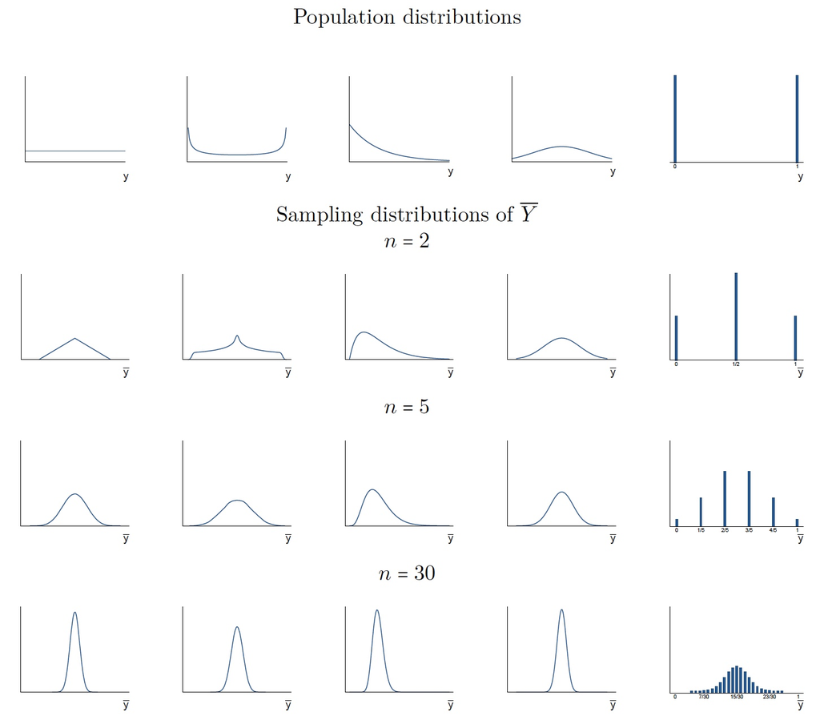

Independente da forma da distribuição original, à medida que $n$ aumenta, a distribuição de $\bar{Y}$ converge para uma distribuição normal

## Teorema Central Do Limite

**Por que a distribuição Normal aparece tanto?**

Em termos práticos, o TCL:

- ajuda a entender por que métodos clássicos usam aproximações normais;
- justifica muitos intervalos e testes em grandes amostras;

## TCL Como Alfabetização Estatística

**O papel do TCL nesta disciplina**

- O TCL é importante para ler artigos, softwares e métodos clássicos.
- Mas ele não será tratado como a única rota para inferência.
- Nas próximas aulas, vamos buscar introduzir também:
- bootstrap para intervalos por reamostragem;
- permutação para construir distribuições nulas;
- interpretação crítica de valores-p;
- tamanho do efeito e significância prática.

# Lista de Exercícios

## Lista de Exercícios

**Site da disciplina**

- A lista de exercícios está disponível na página **Cronograma** (Aula 10) do site da disciplina.

## Referências

BILLINGSLEY, P. **[Probability and Measure](https://www.wiley.com/en-us/Probability%2Band%2BMeasure%2C%2BAnniversary%2BEdition-p-9781118122372)**. Anniversary Edition ed. Hoboken, NJ: Wiley, 2012.

BLITZSTEIN, J. K.; HWANG, J. **[Introduction to Probability](https://drive.google.com/file/d/1VmkAAGOYCTORq1wxSQqy255qLJjTNvBI/edit)**. 1. ed. Boca Raton: Chapman; Hall/CRC, 2014.

DEVORE, J. L. **Probabilidade e Estatística para Engenharia e Ciências**. São Paulo: Thomson, 2006.

JAMES, B. R. **[Probabilidade: um curso em nível intermediário](https://impa.br/books/probabilidade-um-curso-em-nivel-intermediario/)**. 5. ed. Rio de Janeiro, Brasil: IMPA, 2023. p. 296

ROSS, S. M. **A First Course in Probability**. 9th. ed. [s.l.] Pearson Education, 2015.